# COVID-19-sicilia-second-wave

Francesco Ortu

1/12/2022

## Data analysis

```r
setwd("/home/francesco/Repository/SMDS")
df <- data.frame(read.csv("covid.sicilia.clean.csv"))
df <- df[,-c(1,2)]
```

```r
summary(df)
```

```
##      data           ricoverati_con_sintomi terapia_intensiva
##  Length:123         Min.   : 303.0         Min.   : 20.0
##  Class :character   1st Qu.: 978.5         1st Qu.:127.0
##  Mode  :character   Median :1226.0         Median :189.0
##                     Mean   :1111.9         Mean   :166.9
##                     3rd Qu.:1426.5         3rd Qu.:214.0
##                     Max.   :1604.0         Max.   :253.0
##
##  totale_ospedalizzati isolamento_domiciliare totale_positivi
##  Min.   : 324         Min.   : 2609          Min.   : 2936
##  1st Qu.:1108         1st Qu.:13776          1st Qu.:14883
##  Median :1424         Median :32628          Median :33868
##  Mean   :1279         Mean   :27471          Mean   :28749
##  3rd Qu.:1648         3rd Qu.:38056          3rd Qu.:39702
##  Max.   :1847         Max.   :46335          Max.   :48001
##
##  variazione_totale_positivi nuovi_positivi   dimessi_guariti    deceduti
##  Min.   :-1909.0            Min.   :  85.0   Min.   : 4026   Min.   : 312
##  1st Qu.:   77.5            1st Qu.: 730.5   1st Qu.: 6912   1st Qu.: 510
##  Median :  338.0            Median :1024.0   Median :22766   Median :1589
##  Mean   :  320.5            Mean   :1048.7   Mean   :33040   Mean   :1584
##  3rd Qu.:  746.5            3rd Qu.:1395.0   3rd Qu.:57672   3rd Qu.:2426
##  Max.   : 1520.0            Max.   :1969.0   Max.   :90336   Max.   :3478
##
##  casi_da_sospetto_diagnostico casi_da_screening  totale_casi
##  Min.   :    0                Min.   :    0     Min.   :  7274
##  1st Qu.: 7142                1st Qu.: 3982     1st Qu.: 22306
##  Median :14130                Median : 8176     Median : 65085
##  Mean   :17477                Mean   :10668     Mean   : 63374
##  3rd Qu.:26891                3rd Qu.:16526     3rd Qu.: 94205
##  Max.   :40116                Max.   :26452     Max.   :136103
##  NA's   :59                   NA's   :59
##     tamponi         casi_testati    ingressi_terapia_intensiva nuovi_tamponi
##  Min.   : 490482   Min.   :358336   Min.   : 6.00              Min.   : 2656
##  1st Qu.: 689048   1st Qu.:485477   1st Qu.:10.75              1st Qu.: 7232
##  Median : 970696   Median :661271   Median :14.00              Median : 8572
##  Mean   : 990492   Mean   :657858   Mean   :13.60              Mean   :10574
##  3rd Qu.:1222880   3rd Qu.:814795   3rd Qu.:16.25              3rd Qu.:10322
##  Max.   :1784459   Max.   :985615   Max.   :23.00              Max.   :44527
##                                     NA's   :63
##     color           nuovi_deceduti
##  Length:123         Min.   : 1.00
##  Class :character   1st Qu.:13.25
##  Mode  :character   Median :29.00
##                     Mean   :25.95
##                     3rd Qu.:36.00
##                     Max.   :49.00
##                     NA's   :1
```

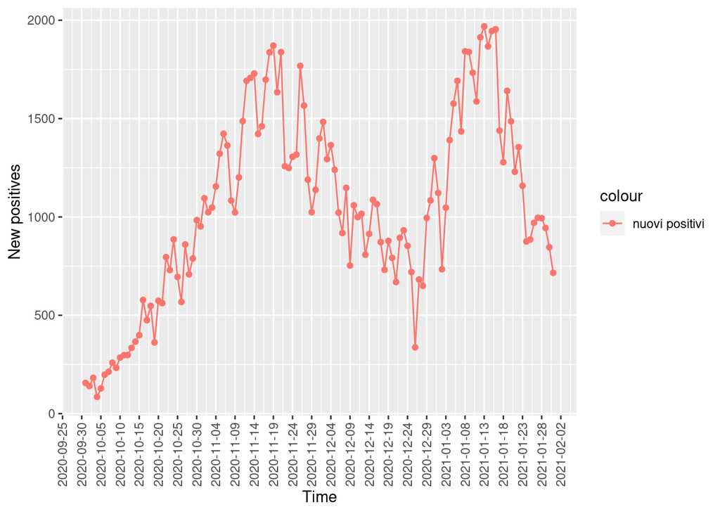

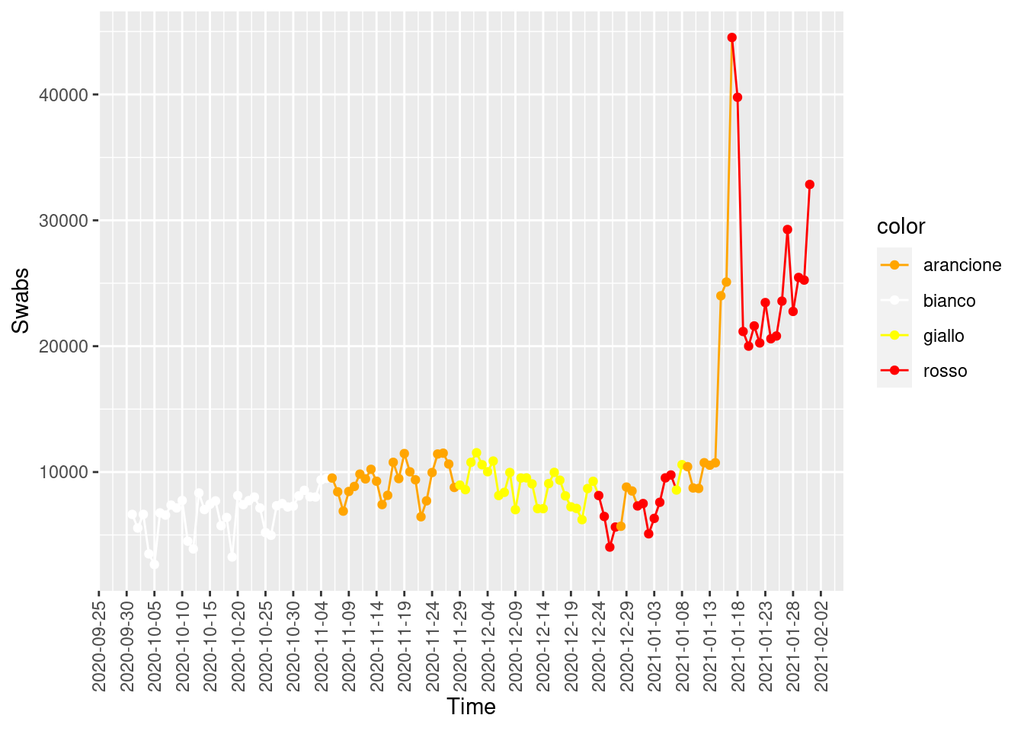

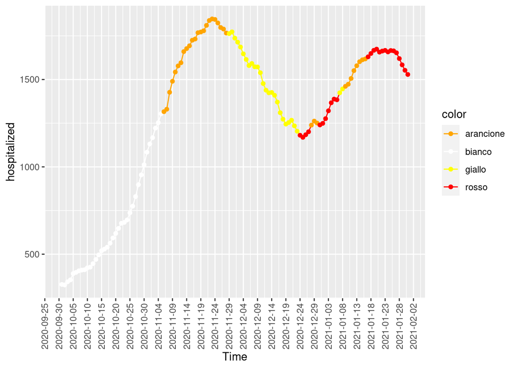

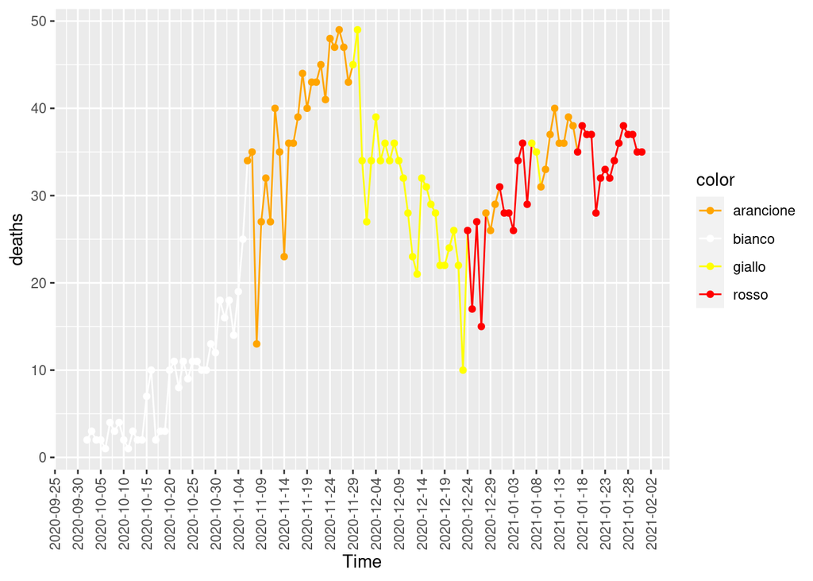

Correlation analysis:

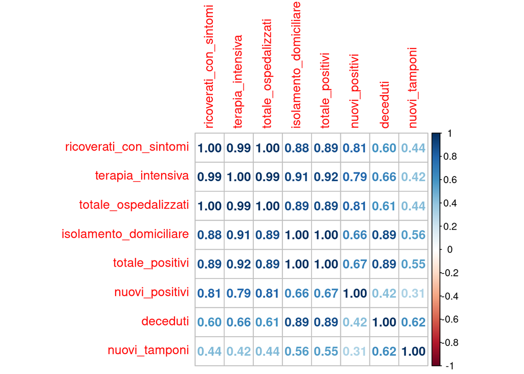

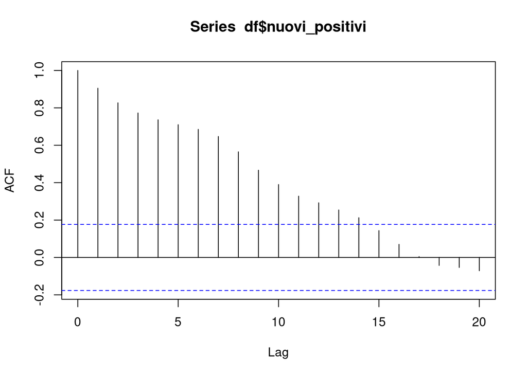

In order to find a model to predict $Y$ I may want to plot some correlation plot. Following the intuition suggested by the values of the correlation matrix (which are shown above), I mainly focused on variables `ricoverati con sintomi`, `terapia intensiva`, `totale ospedalizzati`:

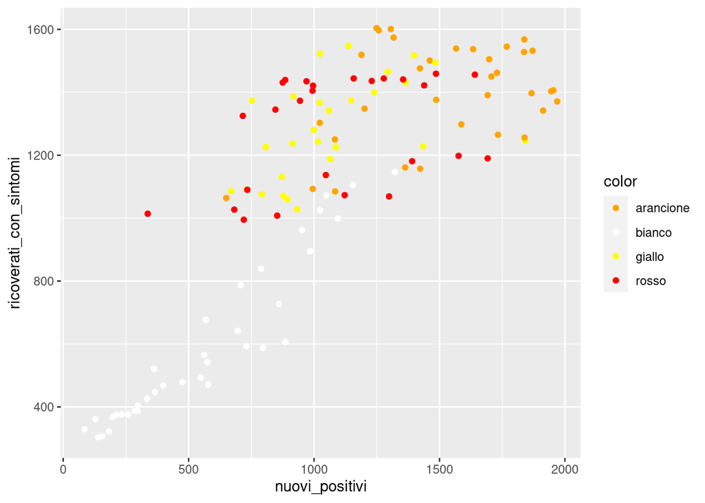

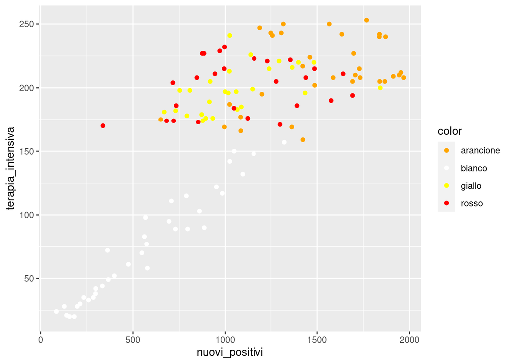

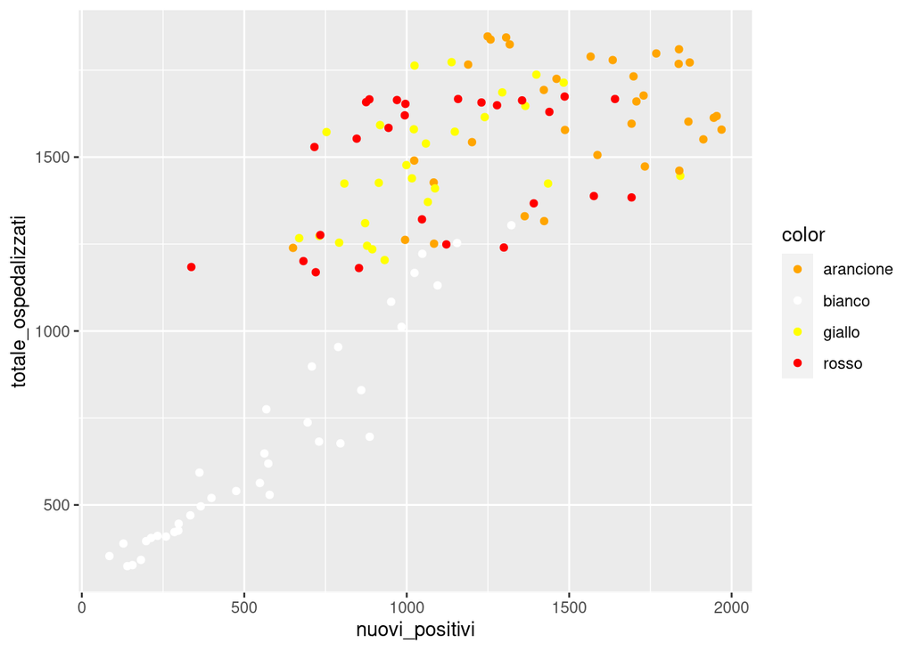

Simply looking this plots we can notice that:

- There is a possible linear correlation between $Y$ and the other variables when the region is white. **Why??** idk, maybe it is because in that time the cases of covid (and consequentially the other variables) grew without any interference such as lockdowns or other containment measures. In my opinion this relationship may represent a bad quality of data: only in 2/3 of the dataset there are containment measures and this could be implies a non-homogeneity of the data. **THIS COULD BE ADD TO THE POINT 2: QUALITY OF DATA.**
- It seems that there are not difference between the point with other colors, apart from the orange ones; this points are quite grouped. However it may depend on the fact that the orange zone followed a yellow zone where the cases were growing, so there is not a “real” correlation between orange color and variables. *(idk what I’m really saying)*
- It will be tough to find a model for this data bc the point, except for the white ones, are quite scattered.

## Find a model

Since the previous observations, especially the *“quasi-linearity”* (with a lot of noise) I fristly will explore some GLM models.

**Because `totale ospedalizzati == ricoverati con sintomi + terapia intensiva` this variables is not useful and I will remove it.**

### **GLM, gaussian family**

This is the default choice of the family.

```r
model <- glm(df$nuovi_positivi ~ df$ricoverati_con_sintomi + df$terapia_intensiva , family = gaussian())
summary(model)
```

```
##
## Call:
## glm(formula = df$nuovi_positivi ~ df$ricoverati_con_sintomi +
##     df$terapia_intensiva, family = gaussian())
##
## Deviance Residuals:
##     Min       1Q   Median       3Q      Max
## -583.86  -188.95   -35.45   168.22   678.89
##
## Coefficients:
##                            Estimate Std. Error t value Pr(>|t|)
## (Intercept)               -107.2523    93.7136  -1.144  0.25471
## df$ricoverati_con_sintomi    1.3275     0.4053   3.276  0.00138 **
## df$terapia_intensiva        -1.9183     2.3589  -0.813  0.41771
## ---
## Signif. codes:  0 '***' 0.001 '**' 0.01 '*' 0.05 '.' 0.1 ' ' 1
##
## (Dispersion parameter for gaussian family taken to be 82787.95)
##
##     Null deviance: 28577350  on 122  degrees of freedom
## Residual deviance:  9934554  on 120  degrees of freedom
## AIC: 1746.9
##
## Number of Fisher Scoring iterations: 2
```

```r
anova(model, test = "F")
```

```
## Analysis of Deviance Table
##
## Model: gaussian, link: identity
##
## Response: df$nuovi_positivi
##
## Terms added sequentially (first to last)
##
##
##                           Df Deviance Resid. Df Resid. Dev        F Pr(>F)
## NULL                                        122   28577350
## df$ricoverati_con_sintomi  1 18588047       121    9989302 224.5260 <2e-16 ***
## df$terapia_intensiva       1    54748       120    9934554   0.6613 0.4177
## ---
## Signif. codes:  0 '***' 0.001 '**' 0.01 '*' 0.05 '.' 0.1 ' ' 1
```

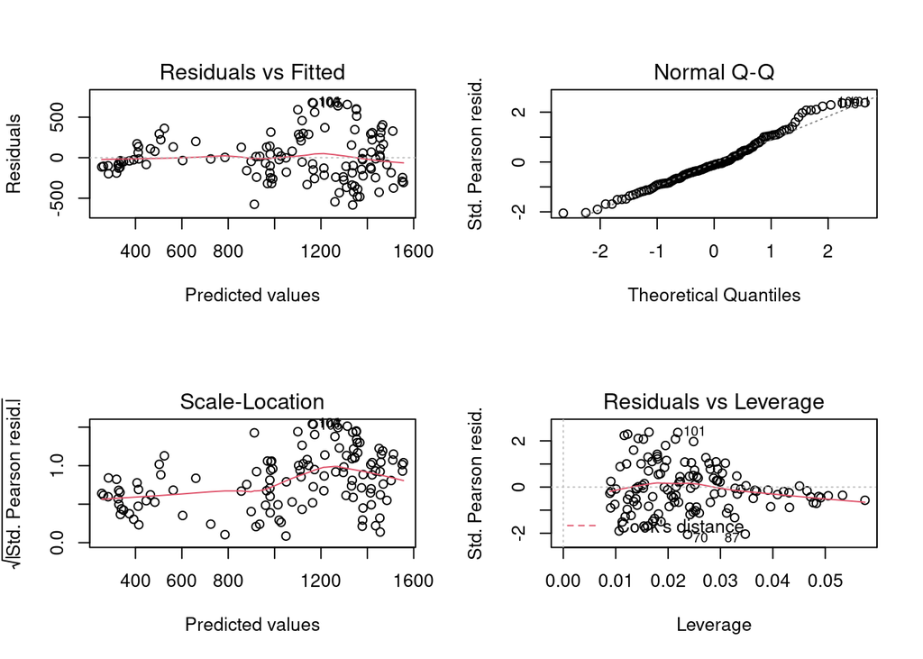

```r
par(mfrow=c(2,2))
plot(model)
```

### GLM, gamma family

```r
model <- glm(df$nuovi_positivi ~ df$ricoverati_con_sintomi + df$terapia_intensiva* df$color , family = Gamma())
summary(model)
```

```
##
## Call:
## glm(formula = df$nuovi_positivi ~ df$ricoverati_con_sintomi +
##     df$terapia_intensiva * df$color, family = Gamma())
##
## Deviance Residuals:
##      Min        1Q    Median        3Q       Max
## -1.03967  -0.23153  -0.00465   0.14141   0.62818
##
## Coefficients:
##                                       Estimate Std. Error t value Pr(>|t|)
## (Intercept)                          1.177e-03  2.959e-04   3.979 0.000122 ***
## df$ricoverati_con_sintomi           -3.173e-07  4.416e-07  -0.719 0.473881
## df$terapia_intensiva                -3.326e-07  2.663e-06  -0.125 0.900836
## df$colorbianco                       2.743e-03  3.707e-04   7.400 2.50e-11 ***
## df$colorgiallo                       9.259e-04  6.811e-04   1.359 0.176678
## df$colorrosso                        2.478e-04  6.493e-04   0.382 0.703451
## df$terapia_intensiva:df$colorbianco -1.902e-05  2.301e-06  -8.263 2.89e-13 ***
## df$terapia_intensiva:df$colorgiallo -3.413e-06  3.287e-06  -1.038 0.301345
## df$terapia_intensiva:df$colorrosso  -1.398e-07  3.096e-06  -0.045 0.964060
## ---
## Signif. codes:  0 '***' 0.001 '**' 0.01 '*' 0.05 '.' 0.1 ' ' 1
##
## (Dispersion parameter for Gamma family taken to be 0.08251213)
##
##     Null deviance: 38.828  on 122  degrees of freedom
## Residual deviance: 10.375  on 114  degrees of freedom
## AIC: 1738.8
##
## Number of Fisher Scoring iterations: 5
```

```r
anova(model, test = "F")
```

```
## Analysis of Deviance Table
##
## Model: Gamma, link: inverse
##
## Response: df$nuovi_positivi
##
## Terms added sequentially (first to last)
##
##
##                               Df Deviance Resid. Df Resid. Dev        F
## NULL                                            122     38.828
## df$ricoverati_con_sintomi      1  21.5287       121     17.300 260.9160
## df$terapia_intensiva           1   0.1348       120     17.165   1.6339
## df$color                       3   0.5240       117     16.641   2.1167
## df$terapia_intensiva:df$color  3   6.2659       114     10.375  25.3132
##                                  Pr(>F)
## NULL
## df$ricoverati_con_sintomi     < 2.2e-16 ***
## df$terapia_intensiva             0.2038
## df$color                         0.1020
## df$terapia_intensiva:df$color 1.265e-12 ***
## ---
## Signif. codes:  0 '***' 0.001 '**' 0.01 '*' 0.05 '.' 0.1 ' ' 1
```

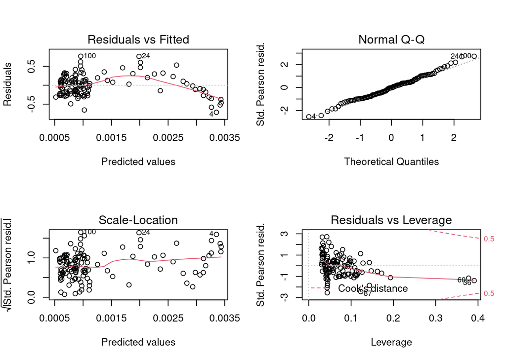

```r
par(mfrow=c(2,2))
plot(model)
```

### GAM

```r
library(mgcv)
gam1 <- gam(nuovi_positivi ~ terapia_intensiva + color + nuovi_tamponi, data = df, family="poisson")
gam2 <- gam(nuovi_positivi ~ terapia_intensiva * color + nuovi_tamponi * color , data = df, family="poisson")
summary(gam1)
```

```
##
## Family: poisson
## Link function: log
##
## Formula:
## nuovi_positivi ~ terapia_intensiva + color + nuovi_tamponi
##
## Parametric coefficients:
##                     Estimate Std. Error z value Pr(>|z|)
## (Intercept)        5.711e+00  2.317e-02 246.442   <2e-16 ***
## terapia_intensiva  7.262e-03  1.082e-04  67.141   <2e-16 ***
## colorbianco        2.956e-03  1.607e-02   0.184    0.854
## colorgiallo       -2.311e-01  7.579e-03 -30.494   <2e-16 ***
## colorrosso        -2.820e-01  9.128e-03 -30.892   <2e-16 ***
## nuovi_tamponi      4.594e-06  5.097e-07   9.014   <2e-16 ***
## ---
## Signif. codes:  0 '***' 0.001 '**' 0.01 '*' 0.05 '.' 0.1 ' ' 1
##
##
## R-sq.(adj) =  0.643   Deviance explained = 70.1%
## UBRE = 73.365  Scale est. = 1         n = 123
```

```r
summary(gam2)
```

```
##
## Family: poisson
## Link function: log
##
## Formula:
## nuovi_positivi ~ terapia_intensiva * color + nuovi_tamponi *
##     color
##
## Parametric coefficients:
##                                 Estimate Std. Error z value Pr(>|z|)
## (Intercept)                    6.480e+00  3.738e-02 173.356  < 2e-16 ***
## terapia_intensiva              2.732e-03  1.684e-04  16.223  < 2e-16 ***
## colorbianco                   -1.567e+00  5.204e-02 -30.109  < 2e-16 ***
## colorgiallo                   -1.179e+00  7.747e-02 -15.213  < 2e-16 ***
## colorrosso                    -1.534e-03  8.266e-02  -0.019    0.985
## nuovi_tamponi                  2.499e-05  1.001e-06  24.969  < 2e-16 ***
## terapia_intensiva:colorbianco  9.370e-03  2.732e-04  34.300  < 2e-16 ***
## terapia_intensiva:colorgiallo -1.504e-04  4.106e-04  -0.366    0.714
## terapia_intensiva:colorrosso  -4.096e-04  4.399e-04  -0.931    0.352
## colorbianco:nuovi_tamponi      2.784e-05  6.181e-06   4.504 6.68e-06 ***
## colorgiallo:nuovi_tamponi      1.023e-04  5.079e-06  20.136  < 2e-16 ***
## colorrosso:nuovi_tamponi      -2.263e-05  1.249e-06 -18.114  < 2e-16 ***
## ---
## Signif. codes:  0 '***' 0.001 '**' 0.01 '*' 0.05 '.' 0.1 ' ' 1
##
##
## R-sq.(adj) =  0.759   Deviance explained = 81.3%
## UBRE = 45.709  Scale est. = 1         n = 123
```

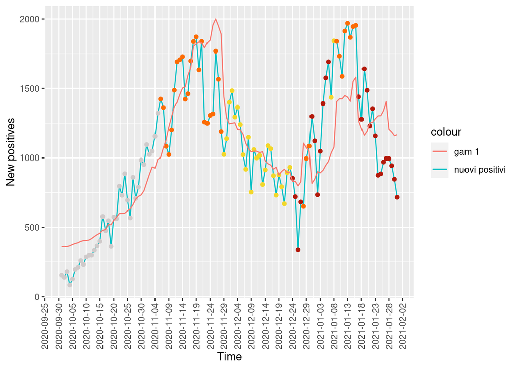

```r
 p<- ggplot() +
  geom_line(data = df, aes(x = data, y = nuovi_positivi, color="nuovi positivi", group = 1)) +
  geom_point(data = df, aes(x = data, y = nuovi_positivi, color="nuovi positivi", group = 1),col=c("#fc6b03","#cfcaca","#f2d729","#b3190b")[unclass(as.factor(df$color))])+
geom_line(data = df, aes(x = data, y = predict(gam1,type="response"), color = "gam 1", group = 1)) +
     labs(x = "Time", y = "New positives") +
  scale_x_date(date_breaks = '5 days',
               date_labels = '%Y-%m-%d') +
  theme(axis.text.x = element_text(angle = 90, vjust = 0.5, hjust=1))

 pp<- ggplot() +
  geom_line(data = df, aes(x = data, y = nuovi_positivi, color="nuovi positivi", group = 1)) +
  geom_point(data = df, aes(x = data, y = nuovi_positivi, color="nuovi positivi", group = 1),col=c("#fc6b03","#cfcaca","#f2d729","#b3190b")[unclass(as.factor(df$color))])+
geom_line(data = df, aes(x = data, y = predict(gam2,type="response"), color = "gam 2", group = 1)) +
     labs(x = "Time", y = "New positives") +
  scale_x_date(date_breaks = '5 days',
               date_labels = '%Y-%m-%d') +
  theme(axis.text.x = element_text(angle = 90, vjust = 0.5, hjust=1))
 p
```

```r
 pp
```

[figure not shown]